# Assignment Prediction Model

Manousos Emmmanouil Theodosiou [6686311], Group: GG Force

11-01-2021

```r
library(MASS)
library(class)
library(ISLR)
library(tidyverse)
```

```r
library(rpart)
library(rpart.plot)
library(randomForest)
```

Load the dataset “accidents_2012_to_2014.csv”

```r
accidents <-
  read_csv("accidents_2012_to_2014.csv")
#View(accidents)

#distinct(accidents, Road_Type)
#distinct(accidents, Weather_Conditions)
#distinct(accidents, Light_Conditions)
#distinct(accidents, Road_Surface_Conditions)
#distinct(accidents, Special_Conditions_at_Site)
#distinct(accidents, Carriageway_Hazards)
```

# Introduction and Description of the Data set

## Exploration

By looking at the dataset it can be seen that in 2012-2014 the most accidents occur on Saturday whereas the least number of accidents take place on Monday. (1 is Monday, 2 is Tuesday, etc).

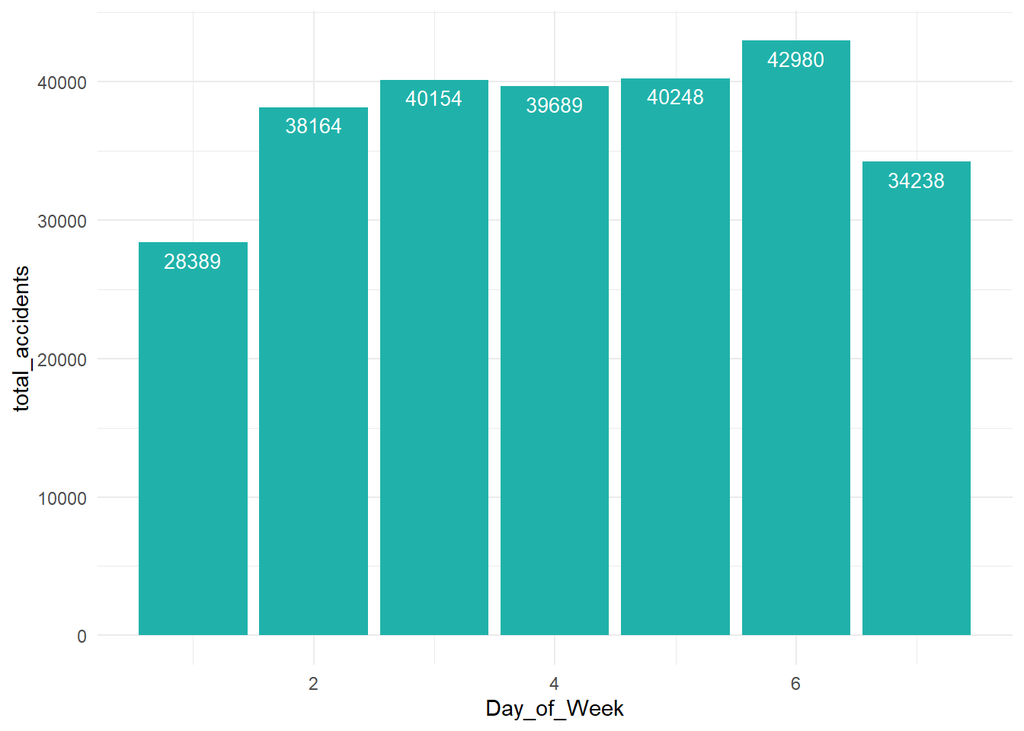

```r
accidents %>%
  group_by(Day_of_Week) %>%
  summarize(total_accidents=n_distinct(Accident_Index)) %>%
    ggplot(aes(x=Day_of_Week, y=total_accidents)) +
    geom_bar(stat="identity", fill="light seagreen")+
    geom_text(aes(label=total_accidents), vjust=1.6, color="white", size=3.5)+
    theme_minimal()
```

We can also visualise the number of accidents by hour. We can see that most accidents take place around 5pm and 8am. This could make sense since people having 9 to 5 jobs are more likely to have an accident on their way to or from their jobs.

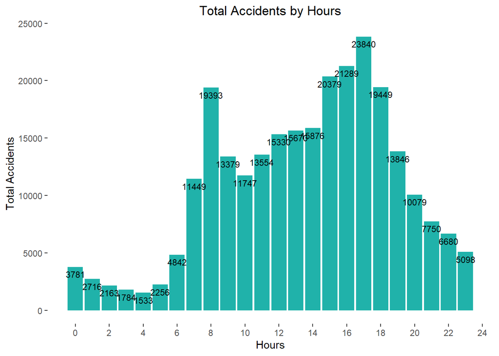

```r
accidents %>%
  mutate(time_slot = as.numeric(substr(Time,0,2))) %>%
  group_by(time_slot) %>%
  summarize(total_accidents=n_distinct(Accident_Index)) %>%
    ggplot(aes(x=time_slot, y=total_accidents)) +
    geom_bar(stat="identity", fill="light seagreen")+
    geom_text(aes(label=total_accidents), vjust=1.6, color="black", size=3)+
    scale_x_continuous(breaks = round(seq(0, 24, by = 2),0)) +
    ggtitle("Total Accidents by Hours") +
    xlab("Hours") + ylab("Total Accidents")+
    theme(plot.title = element_text(hjust = 0.5), panel.background = element_blank())
```

Here, we will analyse the probability of having an accident (1 for Fatal, 2 for Serious, 3 for Slight) in a given hour.

```r
accidents_time <-
  accidents %>%
  mutate(time_slot = as.numeric(substr(Time,0,2)))

accidents_time_severity <- table(accidents_time$time_slot, accidents_time$Accident_Severity)
prop.table(accidents_time_severity,1)
```

```
##
##                1           2           3
##   0  0.024660912 0.193279901 0.782059186
##   1  0.027365295 0.198345354 0.774289351
##   2  0.027527792 0.215987295 0.756484913
##   3  0.035087719 0.212759171 0.752153110
##   4  0.033788914 0.190964313 0.775246773
##   5  0.030287860 0.186733417 0.782978723
##   6  0.016501269 0.161435495 0.822063236
##   7  0.010392666 0.138536203 0.851071131
##   8  0.005421950 0.115201866 0.879376184
##   9  0.008179352 0.120867944 0.870952704
##   10 0.012230988 0.137061762 0.850707250
##   11 0.011454707 0.133287461 0.855257832
##   12 0.008774781 0.134004983 0.857220236
##   13 0.010484363 0.135614520 0.853901117
##   14 0.009860953 0.139720488 0.850418558
##   15 0.009607398 0.143086550 0.847306052
##   16 0.009631878 0.144372609 0.845995514
##   17 0.009104668 0.137492314 0.853403018
##   18 0.009172923 0.145101720 0.845725357
##   19 0.012288136 0.150762712 0.836949153
##   20 0.011418584 0.158461987 0.830119429
##   21 0.014671048 0.167112402 0.818216551
##   22 0.020226108 0.171524466 0.808249426
##   23 0.022077620 0.176504764 0.801417616
```

```r
View(accidents_time)
```

Now we will choose only the relevant predictors for the response variable Accident_Severity and make a dataframe.

```r
variables <- names(accidents_time) %in% c("Accident_Severity",
                                 "Number_of_Vehicles",
                                 "Number_of_Casualties",
                                 "Day_of_Week",
                                 "time_slot",
                                 "Road_Type",
                                 "Speed_limit",
                                 "Light_Conditions",
                                 "Weather_Conditions",
                                 "Road_Surface_Conditions"
                                 )

accident_new <- data.frame(accidents_time[variables])
```

Initially we ran all our models on the unfiltered data, but soon it became clear that the classes are very disproportionately distributed as can be seen in the graph below.

Prior probabilities of groups: 1 2 3 0.01141174 0.14371515 0.84487311

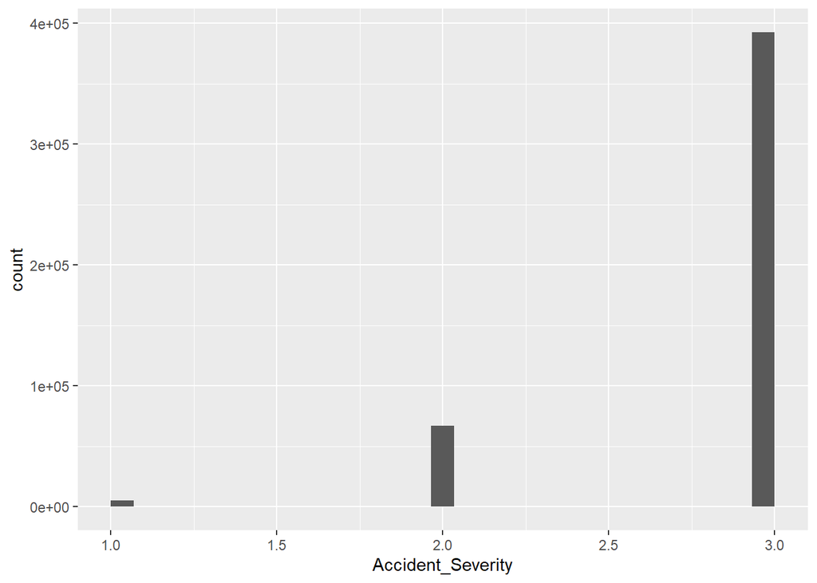

```r
ggplot(accident_new, aes(x=Accident_Severity)) + geom_histogram()
```

We decided then to downsample to make classes more equal. The new distribution:

Prior probabilities of groups: 1 2 3 0.1666667 0.3333333 0.5000000

```r
# Downsampling to make classes equally largge


sev_1 <- accident_new %>%
  filter( Accident_Severity == 1)

sev_2 <- accident_new %>%
  filter( Accident_Severity == 2)

sev_3 <- accident_new %>%
  filter( Accident_Severity == 3)

dim(sev_1)
```

```
## [1] 5303   10
```

```r
dim(sev_2)
```

```
## [1] 66784    10
```

```r
dim(sev_3)
```

```
## [1] 392610     10
```

```r
set.seed(5)

df_balanced <- rbind(sev_1, sample_n(sev_2, 2 * nrow(sev_1)), sample_n(sev_3,  3 * nrow(sev_1)))
accidents_df<- df_balanced
```

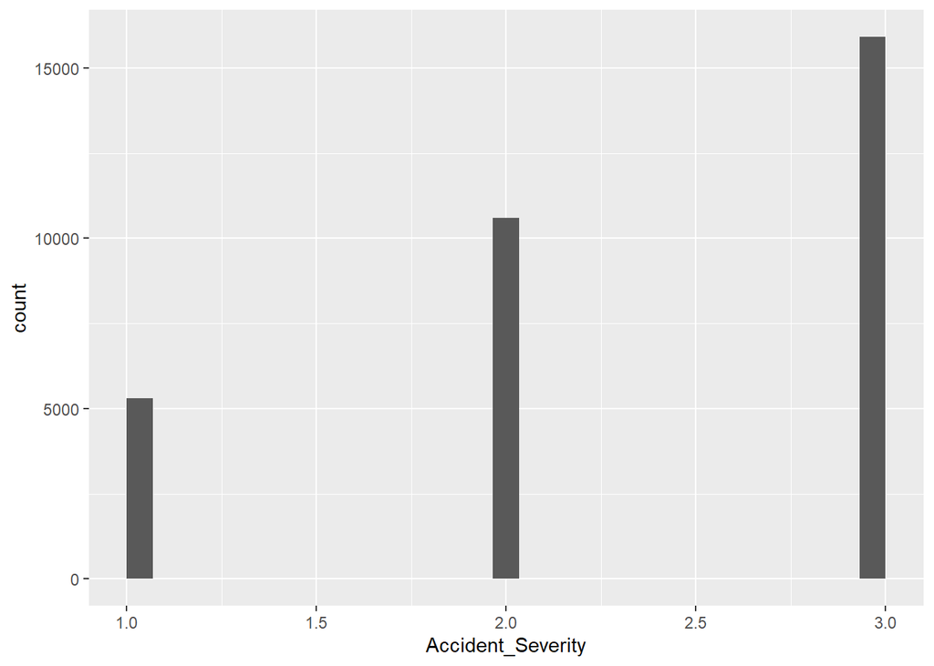

```r
ggplot(accidents_df, aes(x=Accident_Severity)) + geom_histogram()
```

We experimented with different distributions. Such as sampling all of the classes equally, or not sampling at all. However, when sampling equally, the accuraccy suffers immensely, as most of the observations will be of class 3, but will be missclassified due to the dissproportionate weight on class 1. If we don’t rebalance at all, the accuraccy goes up very high, however, this is only due to the unequal distribution. A ‘dumb classifier’ that puts everything in class 3 would already have an accuracy of 84%. Yet, since class one means fatal accidents, it’s important that these don’t get underpredicted since these have the highest impact. It is for this reason that we shifted the distribution to a 1:2:3 balancing, so that this class does not get underpredicted.

Check the type of each column by running the sapply() function. Changed Accident_Severity to factor, making the tree plots behave better.

```r
accidents_df$Accident_Severity <- as.factor(accidents_df$Accident_Severity)  # change to factor to make trees nicer

sapply(accidents_df, class)
```

```
##       Accident_Severity      Number_of_Vehicles    Number_of_Casualties
##                "factor"               "numeric"               "numeric"
##             Day_of_Week               Road_Type             Speed_limit
##               "numeric"             "character"               "numeric"
##        Light_Conditions      Weather_Conditions Road_Surface_Conditions
##             "character"             "character"             "character"
##               time_slot
##               "numeric"
```

Make classification trees using the rpart() function.

Using all predictors:

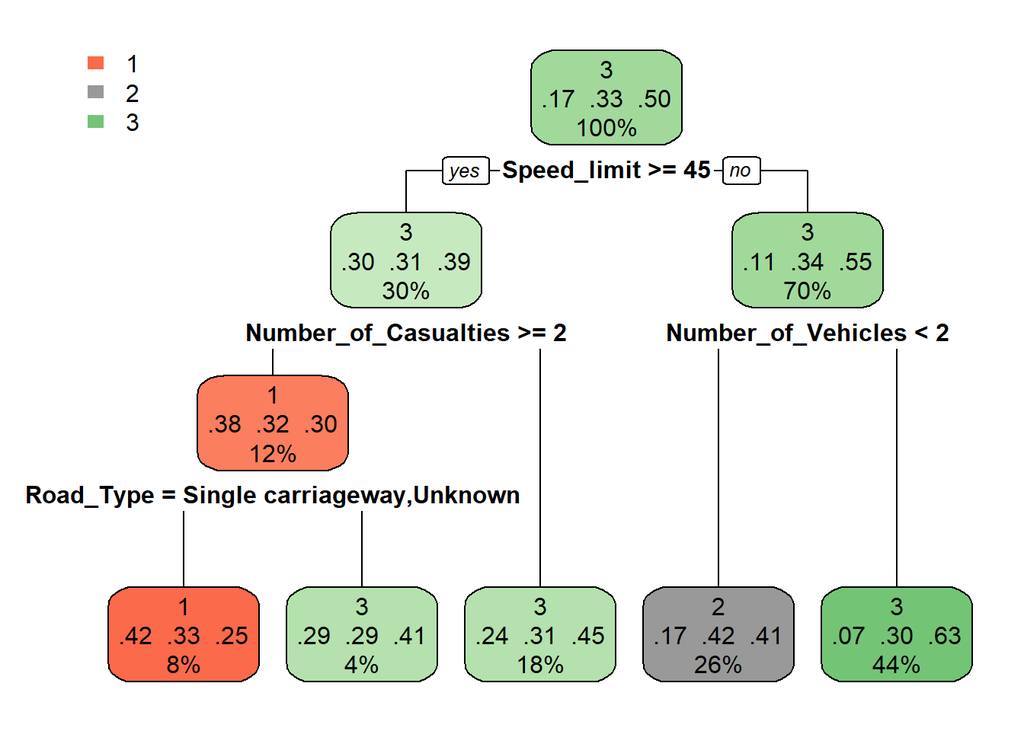

```r
set.seed(1)
accidents_tree_mod <- rpart(Accident_Severity ~ ., data = accidents_df,
                            control=rpart.control(minsplit=20, cp=0.005))
rpart.plot(accidents_tree_mod)
```

The classifcationt tree above is well behaved and setting the minsplit and cp values as they are, it is still possible to read the chart as well as making sure not to overfit on the training data.

## Random Forest for classification

In addition to the tree classifier we want to fit a random forest on all of the chosen variables.

```r
accidents_rf <- randomForest(Accident_Severity ~ ., data = accidents_df, importance = TRUE, na.action = na.exclude)
accidents_rf
```

```
##
## Call:
##  randomForest(formula = Accident_Severity ~ ., data = accidents_df,      importance = TRUE, na.action = na.exclude)
##                Type of random forest: classification
##                      Number of trees: 500
## No. of variables tried at each split: 3
##
##         OOB estimate of  error rate: 47.24%
## Confusion matrix:
##      1    2     3 class.error
## 1 1521 1457  2320   0.7129105
## 2 1019 2988  6584   0.7178737
## 3  867 2762 12251   0.2285264
```

Importance

```r
importance(accidents_rf)
```

```
##                                 1           2         3 MeanDecreaseAccuracy
## Number_of_Vehicles       62.39207  54.3717058 123.38865            134.52703
## Number_of_Casualties     86.60503  14.4511423  34.57495             87.22366
## Day_of_Week              39.61440   3.5573028  15.15447             29.67067
## Road_Type                42.65553  -5.6287063  22.07416             39.79452
## Speed_limit             127.81924  -6.9384526  52.93978            112.14402
## Light_Conditions         52.61968 -11.4360179  43.62285             67.17362
## Weather_Conditions       17.20927  -2.4756194  31.29494             39.76948
## Road_Surface_Conditions  21.18964  -2.3452268  34.28343             48.75079
## time_slot                34.42757   0.4285678  45.63082             65.72575
##                         MeanDecreaseGini
## Number_of_Vehicles              794.2740
## Number_of_Casualties            578.2377
## Day_of_Week                    1215.3783
## Road_Type                       415.1052
## Speed_limit                     809.1075
## Light_Conditions                460.7021
## Weather_Conditions              535.5414
## Road_Surface_Conditions         403.4877
## time_slot                      1799.0762
```

Plot importance

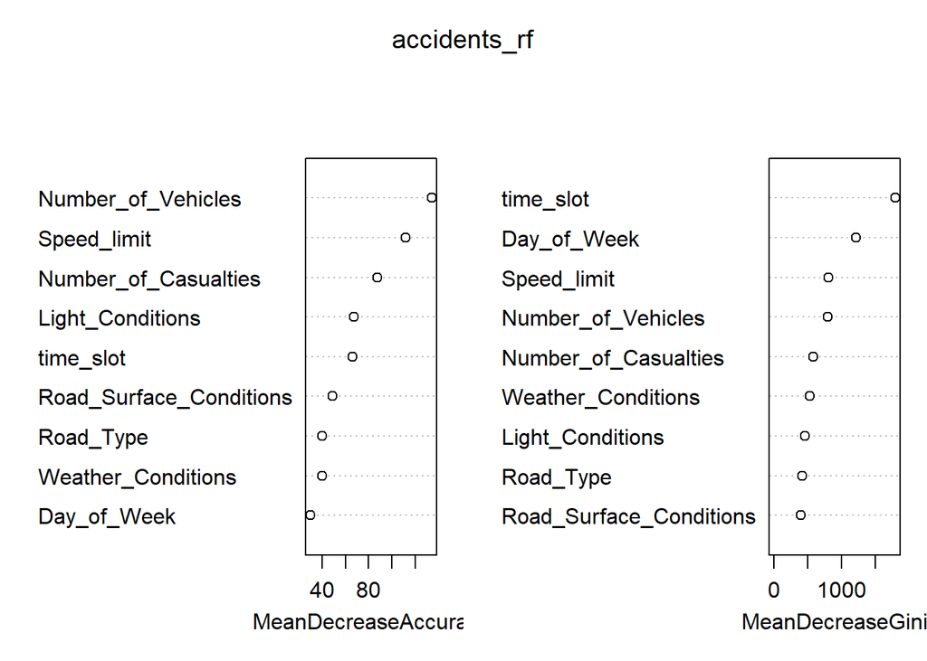

```r
varImpPlot(accidents_rf)
```

Next we will look at the prediction accuracy for the training data set:

```r
prediction_rf_train <- predict(accidents_rf, newdata = accidents_df, na.action = na.exclude)


conf_rf <- table(predicted = prediction_rf_train, true = accidents_df$Accident_Severity)

conf_rf
```

```
##          true
## predicted     1     2     3
##         1  2828   347   306
##         2   871  5391  1557
##         3  1599  4853 14017
```

```r
acc <- (sum(conf_rf[1,1] + conf_rf[2,2] + conf_rf[3,3]) / sum(conf_rf))

## Print 'accuracy' result (sum of diagonal entires/sum of all entries)
paste(round(acc*100, 2), "%", sep="")
```

```
## [1] "69.99%"
```

Now we look at all of the data:

```r
prediction_rf_test <- predict(accidents_rf, newdata = accident_new, na.action = na.exclude)


conf_test_rf <- table(predicted = prediction_rf_test, true = accident_new$Accident_Severity)

conf_test_rf
```

```
##          true
## predicted      1      2      3
##         1   2828   5997  20101
##         2    872  21016  65894
##         3   1598  39676 305947
```

```r
acc <- (sum(conf_test_rf[1,1] + conf_test_rf[2,2] + conf_test_rf[3,3]) / sum(conf_test_rf))

## Print 'accuracy' result (sum of diagonal entires/sum of all entries)
paste(round(acc*100, 2), "%", sep="")
```

```
## [1] "71.09%"
```

Interestingly, the accuracy for the whole data set is actually higher, given the data imbalance.

## LDA Analysis

In addition to the random forest, we also take a look at an LDA model to predict the severity. Here we picked out the most important factors to base our formula on:

```r
# Fit lda model, i.e. calculate model parameters, using 'integer' variables only, we will use the 'factor' variables to map plots later
accident_lda <- lda(Accident_Severity ~ Number_of_Vehicles + Number_of_Casualties + Day_of_Week + Speed_limit + Light_Conditions + Weather_Conditions, data = accidents_df)


accident_lda
```

```
## Call:
## lda(Accident_Severity ~ Number_of_Vehicles + Number_of_Casualties +
##     Day_of_Week + Speed_limit + Light_Conditions + Weather_Conditions,
##     data = accidents_df)
##
## Prior probabilities of groups:
##         1         2         3
## 0.1666667 0.3333333 0.5000000
##
## Group means:
##   Number_of_Vehicles Number_of_Casualties Day_of_Week Speed_limit
## 1           1.749199             1.773902    4.082029    47.60890
## 2           1.680464             1.400245    4.120781    39.47954
## 3           1.849959             1.316236    4.100886    38.05079
##   Light_ConditionsDarkness: Street lighting unknown
## 1                                        0.01056006
## 2                                        0.01433151
## 3                                        0.01439437
##   Light_ConditionsDarkness: Street lights present and lit
## 1                                               0.2029040
## 2                                               0.2047897
## 3                                               0.1966183
##   Light_ConditionsDarkness: Street lights present but unlit
## 1                                               0.009617198
## 2                                               0.005374316
## 3                                               0.005468603
##   Light_ConditionsDaylight: Street light present
## 1                                      0.6041863
## 2                                      0.7062983
## 3                                      0.7375699
##   Weather_ConditionsFine without high winds Weather_ConditionsFog or mist
## 1                                 0.8365076                   0.009994343
## 2                                 0.8234961                   0.005091458
## 3                                 0.7969703                   0.005782890
##   Weather_ConditionsOther Weather_ConditionsRaining with high winds
## 1              0.01150292                                0.01527437
## 2              0.01348293                                0.01282293
## 3              0.01791439                                0.01672010
##   Weather_ConditionsRaining without high winds
## 1                                   0.09654912
```

[output cut: 35 more lines]

```
## Light_ConditionsDarkness: Street lights present and lit   -0.50468203
## Light_ConditionsDarkness: Street lights present but unlit  0.36583251
## Light_ConditionsDaylight: Street light present            -0.54030063
## Weather_ConditionsFine without high winds                  0.15475559
## Weather_ConditionsFog or mist                              1.45401220
## Weather_ConditionsOther                                    1.11066532
## Weather_ConditionsRaining with high winds                  1.40357933
## Weather_ConditionsRaining without high winds               0.56305604
## Weather_ConditionsSnowing with high winds                  0.59942567
## Weather_ConditionsSnowing without high winds               0.55075159
## Weather_ConditionsUnknown                                  0.72003650
##
## Proportion of trace:
##    LD1    LD2
## 0.9155 0.0845
```

```r
## Create a confusion matrix and assess model performance on the 'test' data set

## Use test data set
accident_pred <- predict(accident_lda, accidents_df)

## Now use the 'class' feature to assess performance
lda_class <- accident_pred$class


## Calculate the accuracy (diagonal entries) for this table
conf_mat <- table(predicted = lda_class, true = accidents_df$Accident_Severity)

conf_mat
```

```
##          true
## predicted     1     2     3
##         1  1289   973   873
##         2   409   487   402
##         3  3605  9146 14634
```

```r
lda_acc <- (sum(conf_mat[1,1] + conf_mat[2,2] + conf_mat[3,3]) / sum(conf_mat))

## Print 'accuracy' result (sum of diagonal entires/sum of all entries)
paste(round(lda_acc*100, 2), "%", sep="")
```

```
## [1] "51.57%"
```

Compare with full data set:

```r
## Create a confusion matrix and assess model performance on the 'test' data set

## Use test data set
accident_pred <- predict(accident_lda, accident_new)

## Now use the 'class' feature to assess performance
lda_class <- accident_pred$class


## Calculate the accuracy (diagonal entries) for this table
conf_mat <- table(predicted = lda_class, true = accident_new$Accident_Severity)

conf_mat
```

```
##          true
## predicted      1      2      3
##         1   1289   6111  21401
##         2    409   3023   9556
##         3   3605  57650 361653
```

```r
lda_acc <- (sum(conf_mat[1,1] + conf_mat[2,2] + conf_mat[3,3]) / sum(conf_mat))

## Print 'accuracy' result (sum of diagonal entires/sum of all entries)
paste(round(lda_acc*100, 2), "%", sep="")
```

```
## [1] "78.75%"
```